# A Deep Dive into Demonstrations from 2021-2025

## 1. Introduction and Methodology

This report analyzes global patterns in demonstration events using data from the Armed Conflict Location & Event Data Project (ACLED). Demonstrations represent a key form of collective political action, ranging from peaceful protests to more confrontational events involving state intervention.

The objective of this analysis is to examine how demonstration activity varies over time and across regions, as well as to assess differences in the intensity of such events, measured through associated fatalities and the extent of state intervention.

To ensure consistency in data coverage, the analysis is restricted to observations from 2021 onwards. This accounts for the significant expansion of ACLED’s geographic coverage over time, as many countries, particularly in Europe and North America, were not comprehensively covered prior to 2021.

Demonstration events are identified using the following ACLED sub-event classifications:

- Peaceful protest
- Protest with intervention
- Excessive force against protesters
- Violent demonstration

These categories are defined by ACLED, and detailed descriptions of each sub-event type can be found in the ACLED Codebook.

See footnotes for ACLED’s codebook and time period coverage details.

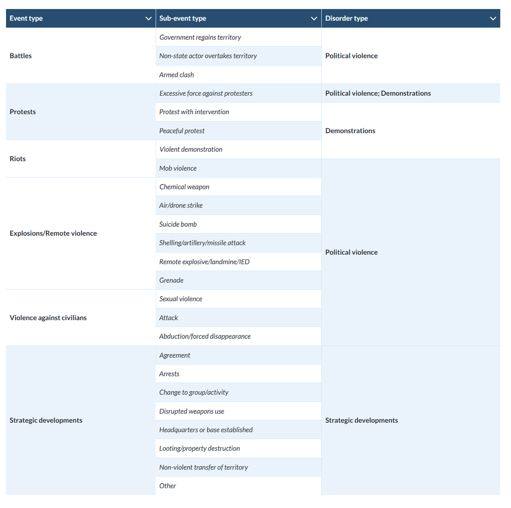

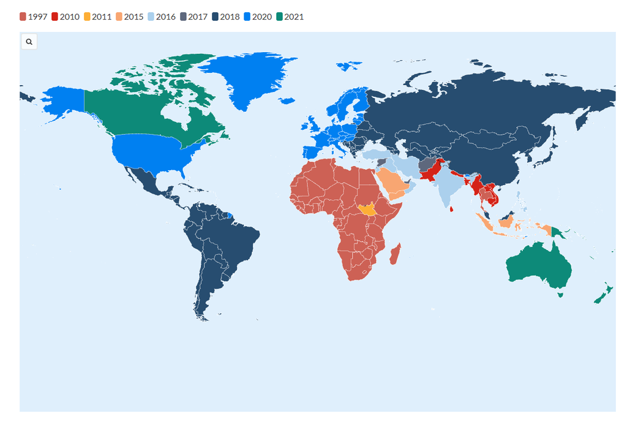

# 2. Temporal Trends in Demonstrations: Timing is Key

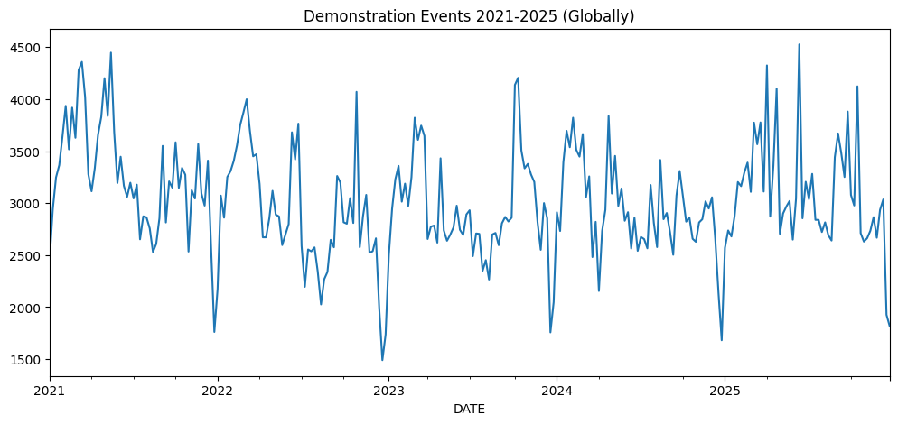

*Figure 1*

Recurring dips at the end of each year are likely attributable to reporting lags and incomplete data coverage, rather than genuine declines in demonstration activity.

Overall, the pattern suggests that demonstration activity is highly dynamic and responsive to short-term political and social conditions.

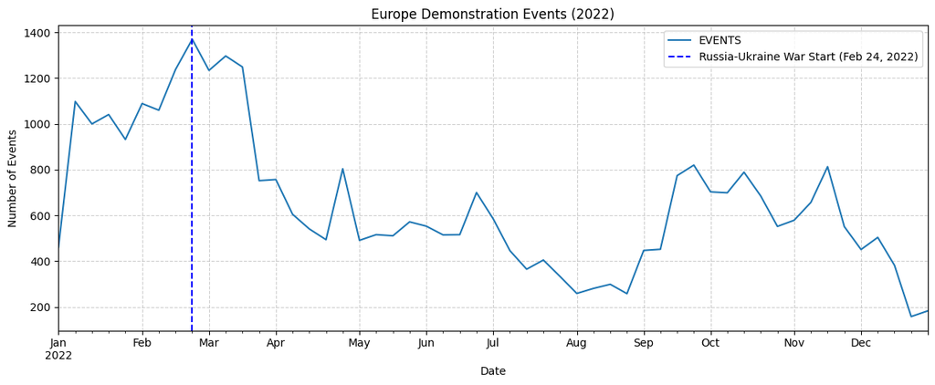

*Figure 2*

A sharp increase in demonstration activity is observed in Europe in early 2022, coinciding with the onset of the Russia–Ukraine war in February 2022. This pattern is consistent with real-world events, as large-scale protests were reported across major European cities in response to the invasion. For example, more than 100,000 people gathered in Berlin, while widespread demonstrations were also documented in cities such as London, Paris, and Prague, reflecting strong public opposition to the conflict and expressions of solidarity with Ukraine.

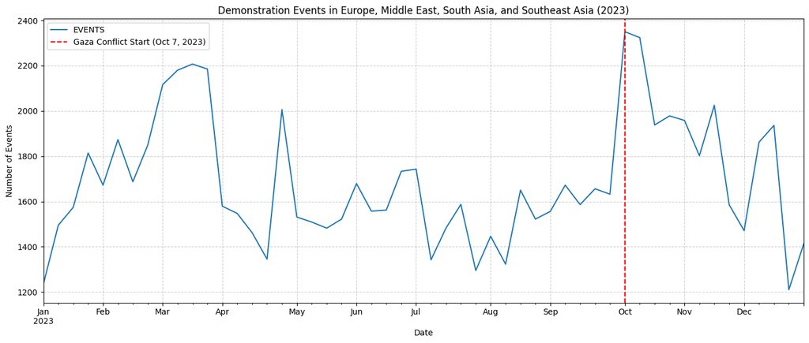

*Figure 3*

Figure 3 displays weekly demonstration events across Europe, the Middle East, South Asia, and Southeast Asia for the year 2023. A vertical dashed line marks the approximate onset of the Gaza conflict on 7 October 2023.

A noticeable increase in demonstration activity is observed across these regions following this date. This pattern is consistent with the earlier case of the Ukraine war, suggesting that major geopolitical shocks can trigger rapid and widespread protest responses beyond the immediate conflict zone. In this instance, the increase likely reflects a global wave of mobilization, including expressions of solidarity with Palestine.

This interpretation is supported by reports of large-scale protests across multiple regions. For example, hundreds of thousands of demonstrators gathered in London in October and November 2023, while significant protests were also recorded in cities such as Paris, Berlin, and New York. In the Middle East, large mobilizations took place in countries including Jordan and Lebanon, while mass demonstrations were also observed in South and Southeast Asia, including Pakistan and Indonesia.

| Month | Total Events |
| --- | --- |
| January | 648 |
| February | 1585 |
| March | 2140 |
| April | 2567 |
| May | 1106 |
| June | 2703 |
| July | 1354 |
| August | 1438 |
| September | 901 |
| October | 2795 |
| November | 985 |
| December | 472 |

*Figure 4: Demonstration Events in the US (2025)*

In addition to global geopolitical events, local domestic issues can also play a significant role in driving protest activity. For example, the “No Kings” protests in the United States, directed against President Donald Trump and his administration, led to a surge in demonstrations across multiple cities.

However, it is important to note that while the temporal alignment is clear, this relationship should be interpreted with caution. The observed increase may also be influenced by other concurrent political and social factors affecting protest activity across regions.

## 3. Regional Distribution of Demonstrations: The Loud Ones

```
REGION
Europe                       174176
South Asia                   153291
North America                107199
Middle East                   98417
South America                 75254
East Asia                     51245
Southeast Asia                36263
Northern Africa               23251
Eastern Africa                13014
Caucasus and Central Asia     11203
Central America               10847
Western Africa                10407
Southern Africa                9316
Oceania                        6303
Caribbean                      5826
Middle Africa                  3721
Antarctica                        9
Name: EVENTS, dtype: int64
```

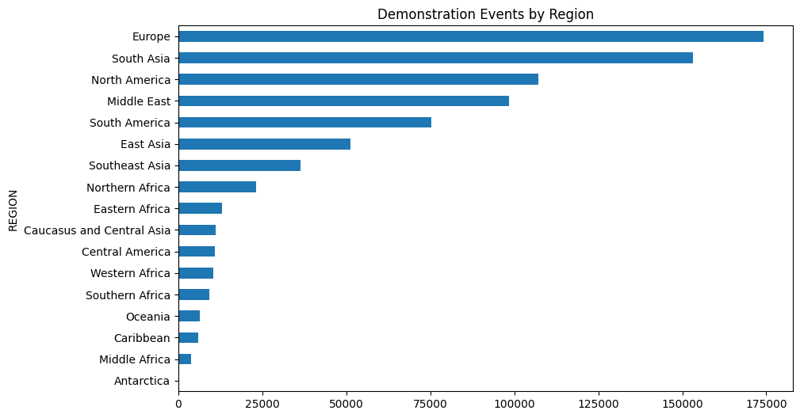

*Figure 5*

Figure 5 shows that demonstration activity is highly uneven across regions, with Europe, South Asia, and North America accounting for the largest share of recorded events.

Several factors may explain this pattern. First, these regions tend to have higher levels of political mobilization and more established traditions of protest, particularly in democratic or semi-democratic contexts where public demonstrations are more feasible. Second, higher population sizes (particularly in South Asia) naturally increase the likelihood of protest events being recorded. Third, differences in media coverage and reporting capacity may contribute to higher event counts, as ACLED relies on open-source reporting, which is more extensive in regions with strong media infrastructures.

By contrast, regions such as Sub-Saharan Africa (labelled as "Middle Africa" by ACLED) and Central Asia record fewer demonstration events. This may reflect a combination of lower reporting density, more restrictive political environments, or different forms of political expression that are less likely to be captured as formal demonstration events.

Overall, the distribution suggests that observed protest activity is shaped not only by underlying political conditions but also by structural factors such as population size, regime type, and data coverage.

```
COUNTRY
India            92177
United States    66409
France           37306
Pakistan         35444
Mexico           31829
South Korea      30591
Turkey           23259
Italy            21564
Germany          20788
Yemen            20139
Spain            19800
Iran             19153
Indonesia        15954
Myanmar          15356
Brazil           13558
Name: EVENTS, dtype: int64
```

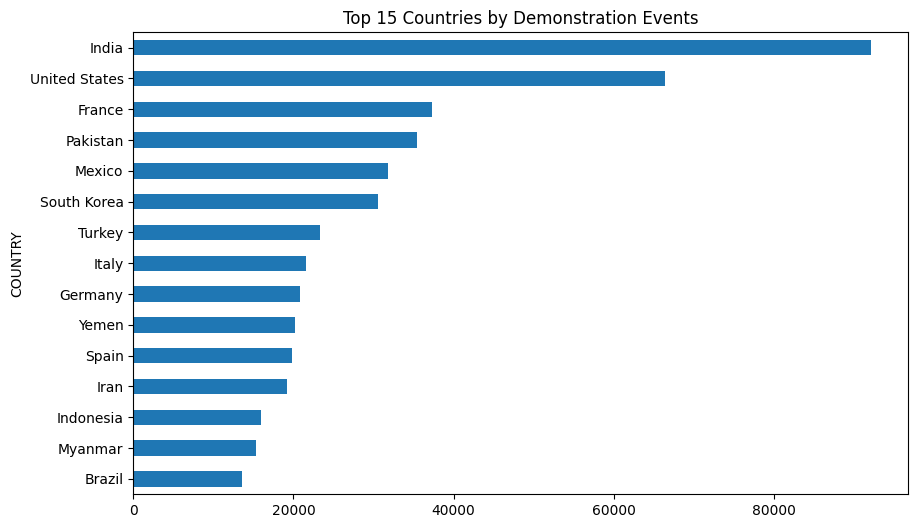

*Figure 6*

Figure 6 highlights the concentration of demonstration activity within a relatively small number of countries, with India and the United States recording the highest number of events by a substantial margin.

In the case of India, the high number of demonstrations can be attributed to its large population, regional diversity, and frequent local-level mobilization around economic, social, and political issues. Similarly, the United States exhibits a high volume of protest activity due to its strong protest culture, institutional protections for assembly, and recurring mobilization around political, social, and economic concerns.

Other countries in the top group, including France, Pakistan, and Mexico, are characterized by recurring political tensions, economic pressures, or contentious policy environments that generate sustained protest activity. In European countries such as France, demonstrations are often linked to labor disputes and policy reforms, while in countries like Pakistan, Iran, or Myanmar, protests may reflect political instability or governance challenges.

## 4. Types of Demonstrations: Not All Protests are Created Equal

```
SUB_EVENT_TYPE
Peaceful protest                      727521
Violent demonstration                  35383
Protest with intervention              24759
Excessive force against protesters      2079
Name: EVENTS, dtype: int64
```

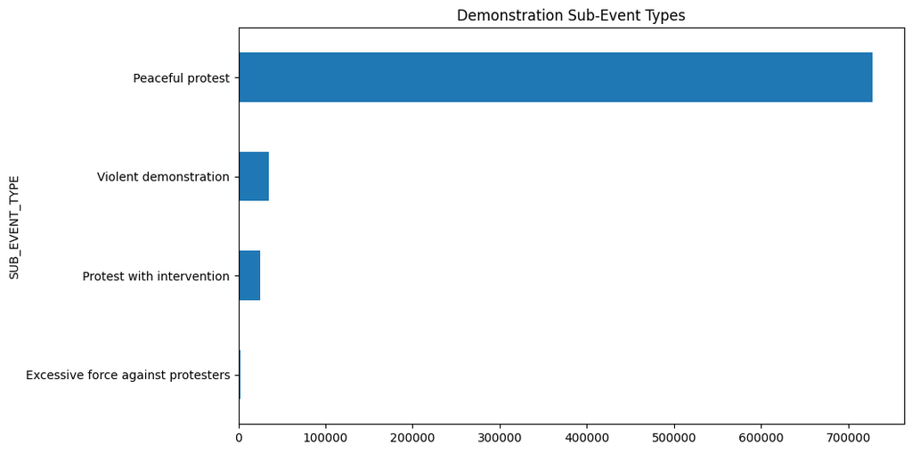

*Figure 7*

While ACLED also categorizes “Violent demonstration” and “Mob violence” under the broader event types of "Riots", this study excludes “Mob violence” from the definition of demonstrations. This is because mob violence involves inherently violent and disorderly interactions that extend beyond the primary purpose of collective political expression, often targeting civilians, property, or other groups. By contrast, the included sub-event types better reflect demonstrations as forms of organized, issue-driven public mobilization, even when they escalate or encounter state intervention.

```
REGION
Middle Africa                0.339156
Caribbean                    0.304154
Eastern Africa               0.270862
Southern Africa              0.250966
Western Africa               0.208514
Middle East                  0.101690
Northern Africa              0.100254
South America                0.098520
Oceania                      0.092020
South Asia                   0.083443
Central America              0.077994
Caucasus and Central Asia    0.073373
Southeast Asia               0.060502
Europe                       0.052430
North America                0.038237
East Asia                    0.018285
Antarctica                   0.000000
Name: EVENTS, dtype: float64
```

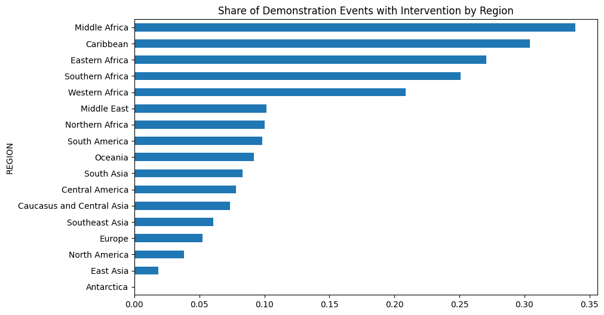

*Figure 8*

Figure 8 presents the share of demonstration events involving intervention across regions. Here, intervention is defined to include the sub-event types “Protest with intervention,” “Excessive force against protesters,” and “Violent demonstration,” capturing instances where demonstrations are met with state or actor responses, and has escalated beyond strictly peaceful forms.

In contrast, regions such as Europe and North America display comparatively lower shares of intervention, indicating that demonstrations in these contexts are more likely to remain peaceful or proceed without significant interference. This may be associated with stronger legal protections for assembly, more institutionalized channels for political participation, and different policing practices.

Overall, these findings suggest that while demonstrations occur globally, the likelihood that they involve intervention or escalate into violence varies significantly across regions, reflecting broader differences in governance, state capacity, and political context.

```
COUNTRY
Eritrea             1.000000
Christmas Island    1.000000
Saudi Arabia        1.000000
Sierra Leone        0.608696
Saint-Martin        0.581395
Turkmenistan        0.500000
Mozambique          0.495609
Haiti               0.488251
Tanzania            0.483333
Guinea-Bissau       0.466667
Benin               0.442478
Madagascar          0.437426
Guinea              0.436508
Gambia              0.433333
Senegal             0.420290
Name: EVENTS, dtype: float64
```

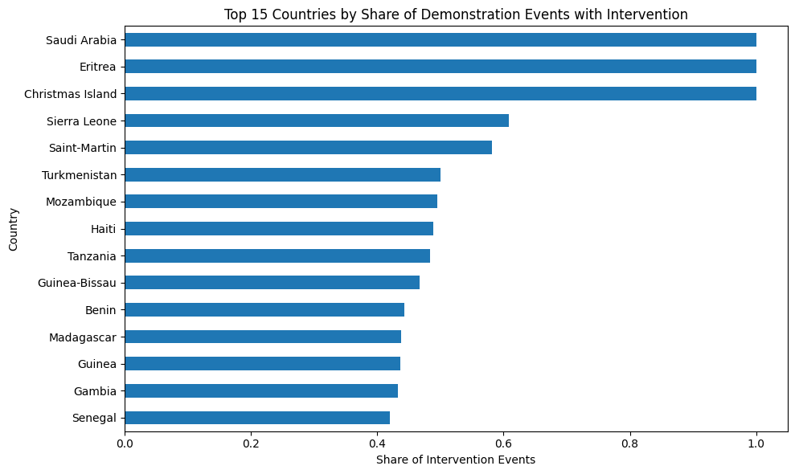

*Figure 9*

Figure 9 presents the top 15 countries by the share of demonstration events involving intervention. The results show that in several countries, a very large proportion of demonstrations involve some form of intervention or escalation.

Notably, countries such as Saudi Arabia and Eritrea exhibit intervention shares close to one, indicating that nearly all recorded demonstrations are met with state intervention or involve coercive responses. This likely reflects highly restrictive political environments in which public demonstrations are either heavily controlled or suppressed, leading to a high likelihood of intervention when protests do occur.

A similar pattern is observed across several countries in Sub-Saharan Africa, including Sierra Leone, Mozambique, Tanzania, and Guinea-Bissau, where a substantial share of demonstrations involve intervention. This may be indicative of more contentious state–society relations, weaker institutional constraints on the use of force, or lower tolerance for public dissent.

However, these results should be interpreted with caution. High intervention shares do not necessarily imply a large volume of protest activity, but rather indicate that when demonstrations occur, they are more likely to involve confrontation or coercion. In some cases, particularly for smaller or less frequently observed territories such as Christmas Island or Saint-Martin, high shares may also reflect a small number of total events, which can exaggerate proportions.

## 5. Fatalities in Demonstrations: Better to Die on Your Feet than to Live on Your Knees

```
COUNTRY
Bangladesh                      1481
Myanmar                          636
Iran                             530
Democratic Republic of Congo     264
Kenya                            236
Mozambique                       228
Kazakhstan                       200
Sudan                            183
Nigeria                          153
Angola                           147
Chad                             145
Somalia                          142
Pakistan                         129
Haiti                            118
Ethiopia                         114
Name: FATALITIES, dtype: int64
```

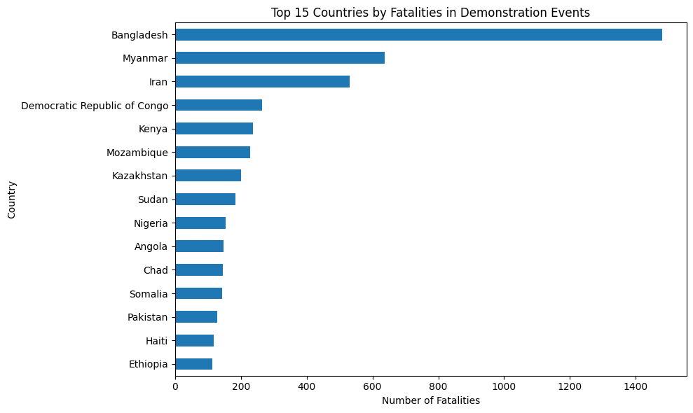

*Figure 10*

Figure 10 illustrates the top 15 countries with the highest number of fatalities directly associated with demonstration events, providing insight into the most violent contexts for public protests.

The data shows a significant concentration of fatalities in a small number of countries, often those experiencing political instability, conflict, or severe state repression. Bangladesh stands out with the highest number of fatalities, which can be attributed to the recent wave of mass protests culminating in the 2024 political crisis and the ousting of Prime Minister Sheikh Hasina. These demonstrations were met with heavy state repression, including the use of live ammunition and widespread arrests, resulting in a high number of casualties.

Myanmar also features prominently, reflecting the aftermath of the 2021 military coup and the subsequent civil conflict. Demonstrations against the junta were frequently met with violent crackdowns, contributing to elevated fatality levels.

In Iran, high fatality counts are closely linked to sustained anti-regime protests and the government's repressive response. Demonstrations driven by economic grievances and opposition to the Islamist regime have often been met with lethal force, including large-scale arrests and reported killings of protesters.

Overall, the figure suggests that fatalities in demonstration events are not evenly distributed, but are concentrated in contexts where protests intersect with conflict dynamics, authoritarian governance, or severe repression, making demonstrations significantly more likely to result in violence.

```
COUNTRY
Tajikistan                      1.769231
Chad                            0.444785
Sierra Leone                    0.391304
Angola                          0.358537
Mozambique                      0.286073
Cameroon                        0.173516
Somalia                         0.159551
Tanzania                        0.154167
Bangladesh                      0.150157
Togo                            0.135593
Democratic Republic of Congo    0.129794
Seychelles                      0.125000
Ethiopia                        0.124183
Rwanda                          0.111111
eSwatini                        0.110032
dtype: float64
```

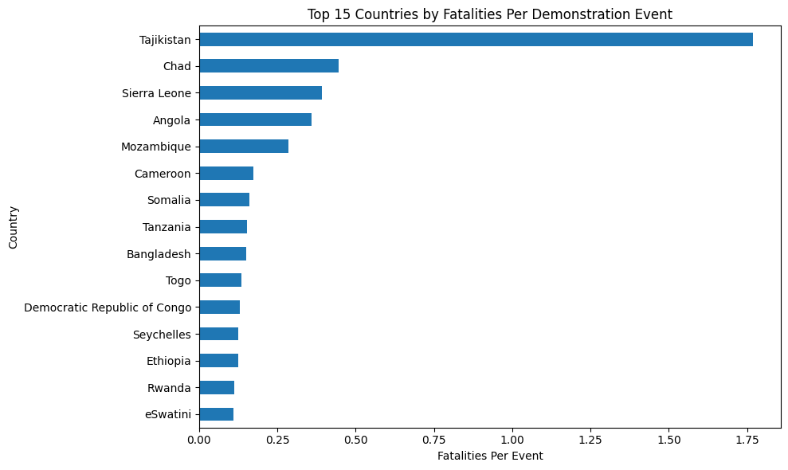

*Figure 11*

Figure 11 presents the top 15 countries ranked by the ratio of fatalities per demonstration event. This metric offers a different perspective compared to total fatalities. A high 'fatalities per event' ratio suggests that when protests do occur, they are met with extreme force, or take place in environments where the risk of death is substantially elevated.

Tajikistan stands out with the highest fatalities per event ratio. This likely reflects relatively infrequent but highly repressed protest activity, where demonstrations are rare but, when they occur, are met with severe and often lethal state responses. In such contexts, even a small number of violent incidents can produce a disproportionately high fatalities-per-event ratio.

More broadly, the prominence of several Sub-Saharan African countries, such as Chad, Sierra Leone, and Mozambique suggests that demonstrations in these contexts tend to be more dangerous on a per-event basis. This may be linked to weaker institutional constraints on the use of force, more frequent involvement of security forces or armed actors, and the overlap between protest activity and broader instability or conflict dynamics.

By contrast, countries like Myanmar and Bangladesh, which dominate in total fatalities, do not appear as prominently in this figure because their high death tolls are spread across a larger number of demonstration events. In other words, while protests in these countries are frequent and often deadly in aggregate, the average lethality per event is lower than in countries where violence is more concentrated in fewer, but more severe, incidents.

```
REGION
South Asia                   1776
Eastern Africa                845
Middle East                   748
Southeast Asia                667
Middle Africa                 647
Western Africa                397
Caucasus and Central Asia     283
South America                 246
Northern Africa               194
Southern Africa               130
Caribbean                     124
North America                  74
Oceania                        21
Europe                         11
Central America                 5
East Asia                       4
Antarctica                      0
Name: FATALITIES, dtype: int64
```

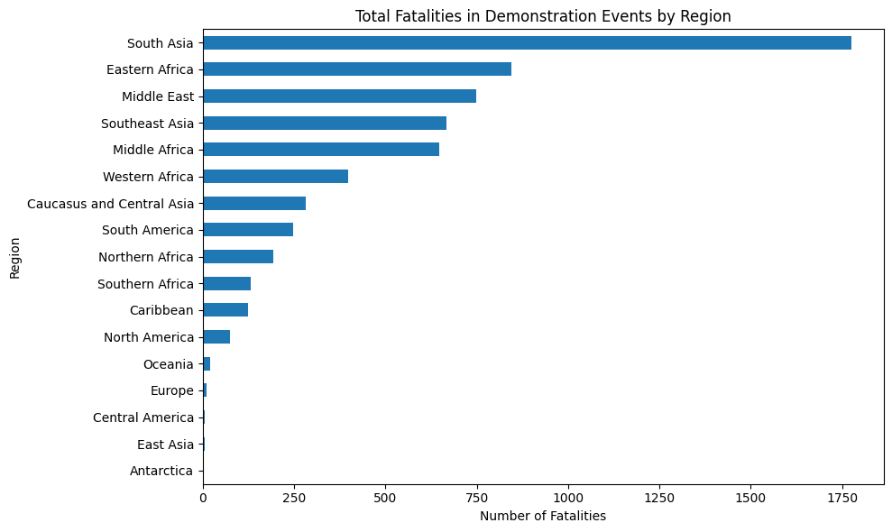

*Figure 12*

Figure 12 illustrates the total number of fatalities in demonstration events across different regions. This chart provides an overview of which regions experience the highest absolute numbers of deaths during protests.

The results highlight significant regional disparities. Regions with ongoing conflicts, political instability, or severe state repression tend to exhibit higher fatality counts. This is often due to the heightened likelihood of violent clashes between protesters and state forces or other armed groups.

While this figure indicates the scale of loss of life, it's important to consider this in conjunction with the total number of demonstration events and the 'fatalities per event' ratio to gain a comprehensive understanding of the risk faced by demonstrators in each region.

```
REGION
Middle Africa                0.173878
Eastern Africa               0.064930
Western Africa               0.038147
Caucasus and Central Asia    0.025261
Caribbean                    0.021284
Southeast Asia               0.018393
Southern Africa              0.013954
South Asia                   0.011586
Northern Africa              0.008344
Middle East                  0.007600
Oceania                      0.003332
South America                0.003269
North America                0.000690
Central America              0.000461
East Asia                    0.000078
Europe                       0.000063
Antarctica                   0.000000
dtype: float64
```

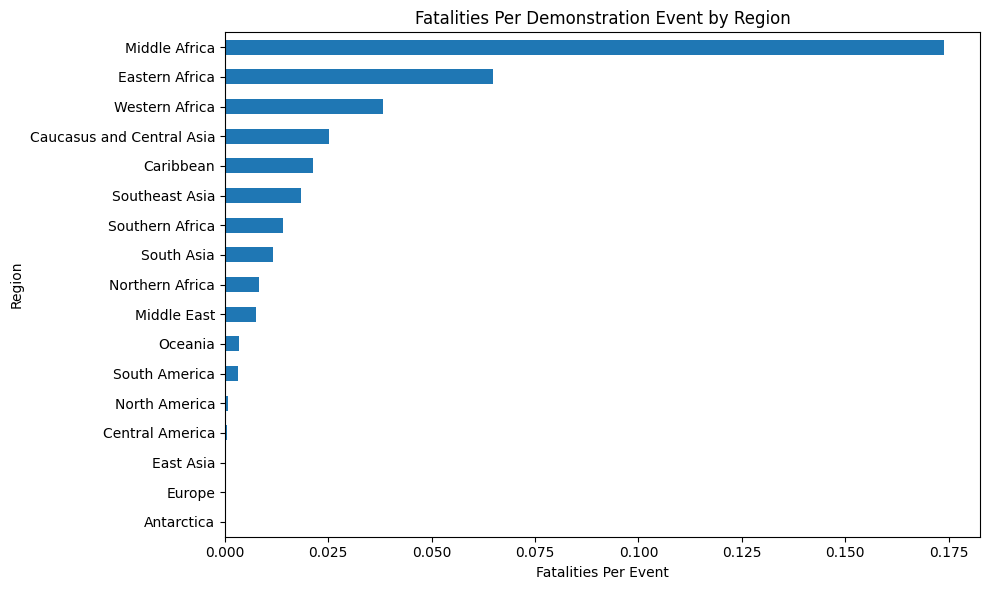

*Figure 13*

Figure 13 illustrates the ratio of fatalities per demonstration event across regions, providing insight into the relative deadliness of protests rather than their overall scale.

This divergence highlights the importance of distinguishing between scale and intensity. In South Asia, high fatality counts are driven by a large number of demonstration events, whereas in parts of Africa, fatalities are more concentrated within individual events. This suggests that protests in these regions are more likely to escalate into severe or violent confrontations, potentially reflecting weaker institutional constraints, greater involvement of armed actors, or the overlap between demonstrations and broader conflict dynamics.

## 6. Conclusion

This report has examined the nature of global demonstration events from 2021 to 2025 using ACLED data, with the central aim of understanding how protest activity varies across time, regions, and in terms of intensity. In doing so, it addressed the research question: how do demonstrations differ globally in both frequency and severity, and what factors help explain these patterns?

The analysis shows that demonstration activity is shaped by both global and domestic dynamics. Major geopolitical events, such as the Ukraine war and the Gaza conflict, are associated with clear and immediate spikes in protest activity across multiple regions, indicating that demonstrations can function as a form of transnational political expression. At the same time, domestic political developments such as leadership crises or policy disputes remain key drivers of localized protest surges.

Taken together, these results highlight that demonstrations are not a uniform phenomenon. Their frequency, form, and outcomes vary significantly depending on political context, institutional constraints, and the nature of state–society relations. By distinguishing between the volume and intensity of protest activity, this report provides a more nuanced understanding of global demonstration dynamics.

Future research could build on these findings by incorporating additional variables such as regime type, economic conditions, or state capacity, in order to more systematically explain why demonstrations in some contexts remain peaceful while in others they escalate into violence.

## *References*

https://acleddata.com/methodology/countrytime-period-coverage

https://acleddata.com/methodology/acled-codebook

## Generate HTML

[output not shown]